# STAT 467-Recitation 6

## Hypothesis Testing in Multivariate Analysis

The theoretical details were given in your recitation notes, you can check them.

### Inference about mean

#### Hotelling $T^2$

As you know, we use Hotelling $T^2$ to test the hypothesis related to mean of one or two population in practice.

$T^2(x):= n (\bar{x}-\mu_0)' \hat \Sigma(x)^{-1} (\bar{x}-\mu_0)$

It is easy to hold this test in R. Like other funcitons, you can figure out several R packages for this test such as `ICSNP` and `DescTools`

```
install.packages("ICSNP")
```

**Example 1 (One Population Mean)**

In this part we’ll consider a dataset which involces 17 overdoses of the drug amitriptyline. There are two responses we want to model: **TOT** and **AMI**.

TOT is total TCAD plasma level and AMI is the amount of amitriptyline present in the TCAD plasma level.

The predictors are as follows:

- GEN, gender (male = 0, female = 1)
- AMT, amount of drug taken at time of overdose ,
- PR, PR wave measurement
- DIAP, diastolic blood pressure
- QRS, QRS wave measurement

```r
ami_data <- read.table("http://static.lib.virginia.edu/statlab/materials/data/ami_data.DAT")
names(ami_data) <- c("TOT","AMI","GEN","AMT","PR","DIAP","QRS")
ami_data
```

```
##     TOT  AMI GEN  AMT  PR DIAP QRS
## 1  3389 3149   1 7500 220    0 140
## 2  1101  653   1 1975 200    0 100
## 3  1131  810   0 3600 205   60 111
## 4   596  448   1  675 160   60 120
## 5   896  844   1  750 185   70  83
## 6  1767 1450   1 2500 180   60  80
## 7   807  493   1  350 154   80  98
## 8  1111  941   0 1500 200   70  93
## 9   645  547   1  375 137   60 105
## 10  628  392   1 1050 167   60  74
## 11 1360 1283   1 3000 180   60  80
## 12  652  458   1  450 160   64  60
## 13  860  722   1 1750 135   90  79
## 14  500  384   0 2000 160   60  80
## 15  781  501   0 4500 180    0 100
## 16 1070  405   0 1500 170   90 120
## 17 1754 1520   1 3000 180    0 129
```

Suppose that we’d like to test the null hypothesis that the observations come from the mean vector of the responses variables $\mu_0^{T}=[1000,1000]$

That means our hypothesis is

$H_0=\mu=\mu_0$ vs $H_1=\mu \neq \mu_0$

First of all create submatrix including your variable of interests.

```r
y<-ami_data[,1:2]
y
```

```
##     TOT  AMI
## 1  3389 3149
## 2  1101  653
## 3  1131  810
## 4   596  448
## 5   896  844
## 6  1767 1450
## 7   807  493
## 8  1111  941
## 9   645  547
## 10  628  392
## 11 1360 1283
## 12  652  458
## 13  860  722
## 14  500  384
## 15  781  501
## 16 1070  405
## 17 1754 1520
```

Then create $\mu_0$ vector.

```r
mu0=c(1000,1000)
```

You know the assumption of this test is that the samples should follow normal distribution.

```r
library(MVN)
test<-mvn(y,mvnTest = "mardia")
test$multivariateNormality
```

```
##              Test        Statistic              p value Result
## 1 Mardia Skewness 27.3129402158504 1.71830311121347e-05     NO
## 2 Mardia Kurtosis 2.72057941974885  0.00651676155890457     NO
## 3             MVN             <NA>                 <NA>     NO
```

The response matrix does not follow normal distribution. In this case, you can apply a solution to solve this problem. However, we’ll assume normality in this example.

Before starting the formal tests, let’s visualize our response matrix.

```
install.packages ("psych")
```

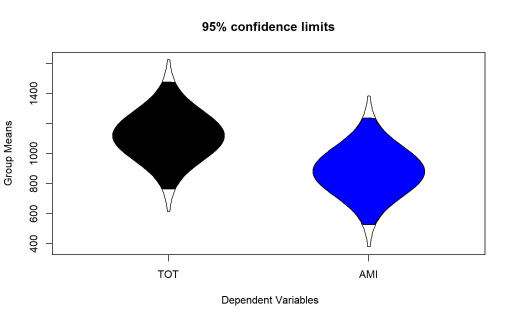

```r
library (psych)
error.bars (y, ylab="Group Means", xlab=" Dependent Variables")
```

```r
library(ICSNP)
HotellingsT2(y,mu=mu0)
```

```
##
##  Hotelling's one sample T2-test
##
## data:  y
## T.2 = 19.725, df1 = 2, df2 = 15, p-value = 6.32e-05
## alternative hypothesis: true location is not equal to c(1000,1000)
```

Since $p<\alpha$ we reject $H_0$. Therefore, we don’t have enough evidence to conclude that the mean vector equals to $(1000,1000)$.

**Example 2 (Two Independent Samples)**

When we compare two independent samples in multivariate analysis, we assume that

- $\Sigma_1=\Sigma_2=\Sigma$
- Both samples follow normal distributions.
- $|\Sigma| > 0$

In this example, we’ll test whether there is a difference in the response variable with respect to gender. In other words, we’ll test that

$H_0=\mu_{female}=\mu_{male}$ vs $H_1=\mu_{female} \neq \mu_{male}$

where

$\mu_{female}=[\mu_{TOT/female}, \mu_{AMI/female}]$

$\mu_{male}=[\mu_{TOT/male}, \mu_{AMI/male}]$

In the previous part, we’ve already proven that the samples do not follow Normal distribution, but we’ll assume it.

```r
HotellingsT2(cbind(ami_data$TOT,ami_data$AMI) ~ ami_data$GEN)
```

```
##
##  Hotelling's two sample T2-test
##
## data:  cbind(ami_data$TOT, ami_data$AMI) by ami_data$GEN
## T.2 = 1.3161, df1 = 2, df2 = 14, p-value = 0.2994
## alternative hypothesis: true location difference is not equal to c(0,0)
```

**Example 3 (Paired Comparison)**

Municipal wastewater treatment plants are required by law to monitor their discharges into rivers and streams on a regular basis. Concern about the reliability of data from one of these self-monitoring programs led to a study in which samples of effluent were divided and sent to two laboratories for testing. One-half of each sample was sent to the Wisconsin State Laboratory of Hygiene, and one-half was sent to a private commercial laboratory routinely used in the monitoring program. Measurements of biochemical oxygen demand (BOD) and suspended solids (SS) were obtained, for n=11 sample splits, from the two laboratories. The data are displayed below.

Do the two laboratories chemical analyses agree? If differences exists what is their nature.

(Question 3 in Recitation 5.)

```r
x1bod<-c(6,6,18,8,11,34,28,71,43,33,20)
x1ss<-c(27,23,64,44,30,75,26,124,54,30,14)
x2bod<-c(25,28,36,35,15,44,42,54,34,29,39)
x2ss<-c(15,13,22,29,37,64,30,64,56,20,21)
d<-data.frame(x1bod,x1ss,x2bod,x2ss)
d
```

```
##    x1bod x1ss x2bod x2ss
## 1      6   27    25   15
## 2      6   23    28   13
## 3     18   64    36   22
## 4      8   44    35   29
## 5     11   30    15   37
## 6     34   75    44   64
## 7     28   26    42   30
## 8     71  124    54   64
## 9     43   54    34   56
## 10    33   30    29   20
## 11    20   14    39   21
```

If you have paired design, you should calculate $D=X_{before}-X_{after}$ The order in difference is up to you.

```r
d1<-d$x1bod-d$x2bod
d2<-d$x1ss-d$x2ss
dy<-cbind(d1,d2)
dy
```

```
##        d1 d2
##  [1,] -19 12
##  [2,] -22 10
##  [3,] -18 42
##  [4,] -27 15
##  [5,]  -4 -7
##  [6,] -10 11
##  [7,] -14 -4
##  [8,]  17 60
##  [9,]   9 -2
## [10,]   4 10
## [11,] -19 -7
```

We need to check normality!

```r
test1<-mvn(dy,mvnTest = "mardia")
test1$multivariateNormality
```

```
##              Test          Statistic           p value Result
## 1 Mardia Skewness   7.76075240425566 0.100745887823685    YES
## 2 Mardia Kurtosis -0.038205741913899 0.969523642854827    YES
## 3             MVN               <NA>              <NA>    YES
```

Normality holds! We can conduct our test without any doubt.

```r
mu0d<-c(0,0)
HotellingsT2(dy,mu=mu0)
```

```
##
##  Hotelling's one sample T2-test
##
## data:  dy
## T.2 = 29113, df1 = 2, df2 = 9, p-value < 2.2e-16
## alternative hypothesis: true location is not equal to c(1000,1000)
```

**Example 4 (One Way MANOVA)**

In this example, we’ll consider the dataset in Example 1. To make the data usable for the analysis, we’ll add a column called drug representing the type of the drug.

```r
ami_data1<-ami_data
ami_data1$drug<-c(rep(1,3),rep(2,2),rep(3,10),rep(4,2))
ami_data1$drug<-as.factor(ami_data1$drug)
ami_data1
```

```
##     TOT  AMI GEN  AMT  PR DIAP QRS drug
## 1  3389 3149   1 7500 220    0 140    1
## 2  1101  653   1 1975 200    0 100    1
## 3  1131  810   0 3600 205   60 111    1
## 4   596  448   1  675 160   60 120    2
## 5   896  844   1  750 185   70  83    2
## 6  1767 1450   1 2500 180   60  80    3
## 7   807  493   1  350 154   80  98    3
## 8  1111  941   0 1500 200   70  93    3
## 9   645  547   1  375 137   60 105    3
## 10  628  392   1 1050 167   60  74    3
## 11 1360 1283   1 3000 180   60  80    3
## 12  652  458   1  450 160   64  60    3
## 13  860  722   1 1750 135   90  79    3
## 14  500  384   0 2000 160   60  80    3
## 15  781  501   0 4500 180    0 100    3
## 16 1070  405   0 1500 170   90 120    4
## 17 1754 1520   1 3000 180    0 129    4
```

We’ll test whether the response variables (TOT and AMI) varies with respect to drug type. In other words, we’ll test

$H_0=\mu_1=\mu_2=\mu_3=\mu_4$ vs $H_1=\text{At least one is different}$ where $\mu_i's$ are mean vector for $i=1,2,3,4$.

Assume that all assumptions are satisfied.

```r
m1 <- manova(cbind(TOT, AMI) ~ drug, data = ami_data1)
summary(m1)
```

```
##           Df  Pillai approx F num Df den Df Pr(>F)
## drug       3 0.74135   2.5524      6     26 0.0445 *
## Residuals 13
## ---
## Signif. codes:  0 '***' 0.001 '**' 0.01 '*' 0.05 '.' 0.1 ' ' 1
```

We’ll interpret this table as usual ANOVA table. The value which should take into account is $Pr(>F)$ value which indicates $p$ value.

Therefore, we are 95% confident that at least one drug type is significantly different than others since $p<\alpha$.

If we reject the null hypothesis in MANOVA, we need to hold a post-hoc analysis to see which one causes the difference. To do so,

[output not shown]

###### NOTE

As you may guess, the difference between manova and two samples test is the number of levels in the treatment (categorical variable.)

The categorical variable in two samples test has two levels such as female and male. However, the one in MANOV has number of levels greater than 2.

## Multivariate Multiple Linear Regression in R

The assumptions of the multivariate linear model concern the behavior of the errors: Let $\varepsilon_{i}^{\prime}$ represent the ith row of $\mathbf{E}$. Then $\varepsilon_{i}^{\prime} \sim \mathbf{N}_{m}(\mathbf{0}, \mathbf{\Sigma}),$ where $\mathbf{\Sigma}$ is a nonsingular error-covariance matrix, constant across cases; $\varepsilon_{i}^{\prime}$ and $\varepsilon_{i}^{\prime}$ are independent for $i \neq i^{\prime} ;$ and $\mathbf{X}$ is fixed or independent of $\mathbf{E}$

The maximum-likelihood estimator of $\mathbf{B}$ in the multivariate linear model is equivalent to equationby-equation least squares for the individual responses:
$$\hat{\mathbf{B}}=\left(\mathbf{X}^{\prime} \mathbf{X}\right)^{-1} \mathbf{X}^{\prime} \mathbf{Y}$$
Procedures for statistical inference in the multivariate linear model, however, take account of the fact that there are several, generally correlated, responses.

Multivariate linear models are fit in R with the `lm()` function. The procedure is the essence of simplicity: The left-hand side of the model is a matrix of responses, with each column representing a response variable and each row a case; the right-hand side of the model and all other arguments to lm are precisely the same as for a univariate linear model. Typically, the response matrix is composed from individual response variables via the `cbind()` function.

**Example 5**

We’ll consider **ami_data** dataset.

```r
mlm1 <- lm(cbind(TOT, AMI) ~ GEN + AMT + PR + DIAP + QRS, data = ami_data)
summary(mlm1)
```

```
## Response TOT :
##
## Call:
## lm(formula = TOT ~ GEN + AMT + PR + DIAP + QRS, data = ami_data)
##
## Residuals:
##    Min     1Q Median     3Q    Max
## -399.2 -180.1    4.5  164.1  366.8
##
## Coefficients:
##               Estimate Std. Error t value Pr(>|t|)
## (Intercept) -2.879e+03  8.933e+02  -3.224 0.008108 **
## GEN          6.757e+02  1.621e+02   4.169 0.001565 **
## AMT          2.848e-01  6.091e-02   4.677 0.000675 ***
## PR           1.027e+01  4.255e+00   2.414 0.034358 *
## DIAP         7.251e+00  3.225e+00   2.248 0.046026 *
## QRS          7.598e+00  3.849e+00   1.974 0.074006 .
## ---
## Signif. codes:  0 '***' 0.001 '**' 0.01 '*' 0.05 '.' 0.1 ' ' 1
##
## Residual standard error: 281.2 on 11 degrees of freedom
## Multiple R-squared:  0.8871, Adjusted R-squared:  0.8358
## F-statistic: 17.29 on 5 and 11 DF,  p-value: 6.983e-05
##
##
## Response AMI :
##
## Call:
## lm(formula = AMI ~ GEN + AMT + PR + DIAP + QRS, data = ami_data)
##
## Residuals:
##     Min      1Q  Median      3Q     Max
## -373.85 -247.29  -83.74  217.13  462.72
##
## Coefficients:
##               Estimate Std. Error t value Pr(>|t|)
## (Intercept) -2.729e+03  9.288e+02  -2.938 0.013502 *
## GEN          7.630e+02  1.685e+02   4.528 0.000861 ***
## AMT          3.064e-01  6.334e-02   4.837 0.000521 ***
## PR           8.896e+00  4.424e+00   2.011 0.069515 .
## DIAP         7.206e+00  3.354e+00   2.149 0.054782 .
## QRS          4.987e+00  4.002e+00   1.246 0.238622
## ---
## Signif. codes:  0 '***' 0.001 '**' 0.01 '*' 0.05 '.' 0.1 ' ' 1
##
## Residual standard error: 292.4 on 11 degrees of freedom
## Multiple R-squared:  0.8764, Adjusted R-squared:  0.8202
## F-statistic:  15.6 on 5 and 11 DF,  p-value: 0.0001132
```

Notice the summary shows the results of two regressions: one for TOT and one for AMI. These are exactly the same results we would get if modeled each separately. You can verify this for yourself by running the following code and comparing the summaries to what we got above. They are identical.

```r
m1 <- lm(TOT ~ GEN + AMT + PR + DIAP + QRS, data = ami_data)
summary(m1)
```

```
##
## Call:
## lm(formula = TOT ~ GEN + AMT + PR + DIAP + QRS, data = ami_data)
##
## Residuals:
##    Min     1Q Median     3Q    Max
## -399.2 -180.1    4.5  164.1  366.8
##
## Coefficients:
##               Estimate Std. Error t value Pr(>|t|)
## (Intercept) -2.879e+03  8.933e+02  -3.224 0.008108 **
## GEN          6.757e+02  1.621e+02   4.169 0.001565 **
## AMT          2.848e-01  6.091e-02   4.677 0.000675 ***
## PR           1.027e+01  4.255e+00   2.414 0.034358 *
## DIAP         7.251e+00  3.225e+00   2.248 0.046026 *
## QRS          7.598e+00  3.849e+00   1.974 0.074006 .
## ---
## Signif. codes:  0 '***' 0.001 '**' 0.01 '*' 0.05 '.' 0.1 ' ' 1
##
## Residual standard error: 281.2 on 11 degrees of freedom
## Multiple R-squared:  0.8871, Adjusted R-squared:  0.8358
## F-statistic: 17.29 on 5 and 11 DF,  p-value: 6.983e-05
```

```r
m2 <- lm(AMI ~ GEN + AMT + PR + DIAP + QRS, data = ami_data)
summary(m2)
```

```
##
## Call:
## lm(formula = AMI ~ GEN + AMT + PR + DIAP + QRS, data = ami_data)
##
## Residuals:
##     Min      1Q  Median      3Q     Max
## -373.85 -247.29  -83.74  217.13  462.72
##
## Coefficients:
##               Estimate Std. Error t value Pr(>|t|)
## (Intercept) -2.729e+03  9.288e+02  -2.938 0.013502 *
## GEN          7.630e+02  1.685e+02   4.528 0.000861 ***
## AMT          3.064e-01  6.334e-02   4.837 0.000521 ***
## PR           8.896e+00  4.424e+00   2.011 0.069515 .
## DIAP         7.206e+00  3.354e+00   2.149 0.054782 .
## QRS          4.987e+00  4.002e+00   1.246 0.238622
## ---
## Signif. codes:  0 '***' 0.001 '**' 0.01 '*' 0.05 '.' 0.1 ' ' 1
##
## Residual standard error: 292.4 on 11 degrees of freedom
## Multiple R-squared:  0.8764, Adjusted R-squared:  0.8202
## F-statistic:  15.6 on 5 and 11 DF,  p-value: 0.0001132
```

The same diagnostics we check for models with one predictor should be checked for these as well. These assumptions about the data, such as :

- Linearity of the data. The relationship between the predictor (x) and the outcome (y) is assumed to be linear.
- Normality of residuals. The residual errors are assumed to be normally distributed.
- Homogeneity of residuals variance. The residuals are assumed to have a constant variance (homoscedasticity)
- Independence of residuals error terms.

We can use Rs extractor functions with our mlm1 object, except we will get double the output. For example, instead of one set of residuals, we get two:

```r
head(resid(mlm1))
```

```
##          TOT        AMI
## 1  132.82172  161.52769
## 2  -72.00392 -264.35329
## 3 -399.24769 -373.85244
## 4 -382.84730 -247.29456
## 5 -152.39129   15.78777
## 6  366.78644  217.13206
```

Instead of one set of fitted values, we get two:

```r
head(fitted(mlm1))
```

```
##         TOT       AMI
## 1 3256.1783 2987.4723
## 2 1173.0039  917.3533
## 3 1530.2477 1183.8524
## 4  978.8473  695.2946
## 5 1048.3913  828.2122
## 6 1400.2136 1232.8679
```

Instead of one set of coefficients, we get two:

```r
coef(mlm1)
```

```
##                       TOT           AMI
## (Intercept) -2879.4782461 -2728.7085444
## GEN           675.6507805   763.0297617
## AMT             0.2848511     0.3063734
## PR             10.2721328     8.8961977
## DIAP            7.2511714     7.2055597
## QRS             7.5982397     4.9870508
```

Instead of one residual standard error, we get two:

```r
sigma(mlm1)
```

```
##      TOT      AMI
## 281.2324 292.4363
```

Again these are all identical to what we get by running separate models for each response. The similarity ends, however, with the variance-covariance matrix of the model coefficients.

```r
vcov(mlm1)
```

```
##                 TOT:(Intercept)       TOT:GEN      TOT:AMT        TOT:PR
## TOT:(Intercept)   797914.009706 -61055.389981 11.236944164 -3.157872e+03
## TOT:GEN           -61055.389981  26262.026594  1.417050110  1.500225e+02
## TOT:AMT               11.236944      1.417050  0.003710048 -1.096946e-01
## TOT:PR             -3157.872390    150.022536 -0.109694600  1.810410e+01
## TOT:DIAP           -1625.349406    162.904357  0.081729026  3.131923e+00
## TOT:QRS            -1414.943019     49.083508 -0.054166512 -4.282235e-01
## AMI:(Intercept)   702227.760065 -53733.596885  9.889404164 -2.779179e+03
## AMI:GEN           -53733.596885  23112.671147  1.247116747  1.320318e+02
## AMI:AMT                9.889404      1.247117  0.003265137 -9.653997e-02
## AMI:PR             -2779.178744    132.031758 -0.096539968  1.593304e+01
## AMI:DIAP           -1430.436687    143.368784  0.071928040  2.756341e+00
## AMI:QRS            -1245.262340     43.197389 -0.047670836 -3.768708e-01
##                      TOT:DIAP       TOT:QRS AMI:(Intercept)       AMI:GEN
## TOT:(Intercept) -1.625349e+03 -1.414943e+03   702227.760065 -53733.596885
## TOT:GEN          1.629044e+02  4.908351e+01   -53733.596885  23112.671147
## TOT:AMT          8.172903e-02 -5.416651e-02        9.889404      1.247117
## TOT:PR           3.131923e+00 -4.282235e-01    -2779.178744    132.031758
## TOT:DIAP         1.040163e+01  2.535578e+00    -1430.436687    143.368784
## TOT:QRS          2.535578e+00  1.481381e+01    -1245.262340     43.197389
## AMI:(Intercept) -1.430437e+03 -1.245262e+03   862755.907989 -66017.011582
## AMI:GEN          1.433688e+02  4.319739e+01   -66017.011582  28396.190973
## AMI:AMT          7.192804e-02 -4.767084e-02       12.150106      1.532206
## AMI:PR           2.756341e+00 -3.768708e-01    -3414.494580    162.214008
## AMI:DIAP         9.154259e+00  2.231510e+00    -1757.432236    176.142660
## AMI:QRS          2.231510e+00  1.303733e+01    -1529.927329     53.072244
##                      AMI:AMT        AMI:PR      AMI:DIAP       AMI:QRS
## TOT:(Intercept)  9.889404164 -2.779179e+03 -1.430437e+03 -1.245262e+03
## TOT:GEN          1.247116747  1.320318e+02  1.433688e+02  4.319739e+01
## TOT:AMT          0.003265137 -9.653997e-02  7.192804e-02 -4.767084e-02
## TOT:PR          -0.096539968  1.593304e+01  2.756341e+00 -3.768708e-01
## TOT:DIAP         0.071928040  2.756341e+00  9.154259e+00  2.231510e+00
## TOT:QRS         -0.047670836 -3.768708e-01  2.231510e+00  1.303733e+01
## AMI:(Intercept) 12.150106211 -3.414495e+03 -1.757432e+03 -1.529927e+03
## AMI:GEN          1.532205650  1.622140e+02  1.761427e+02  5.307224e+01
## AMI:AMT          0.004011543 -1.186089e-01  8.837068e-02 -5.856831e-02
## AMI:PR          -0.118608851  1.957531e+01  3.386437e+00 -4.630228e-01
## AMI:DIAP         0.088370675  3.386437e+00  1.124691e+01  2.741630e+00
## AMI:QRS         -0.058568314 -4.630228e-01  2.741630e+00  1.601764e+01
```

For more details [click](https://socialsciences.mcmaster.ca/jfox/Books/Companion/appendices/Appendix-Multivariate-Linear-Models.pdf)

## Exercise

### Exercise 1

**Solve Question 1 in Recitation 6 in R**

### Quiz

**You can submit your quizzes until December,16, 2020 at 23.59 to ODTUClass**

**Estimate the coefficients of the MLR for data in Question 2 in Recitation 6**

Note: I don’t expect a interpretation, just coding.